# Analyse des impacts de deux types de thérapies de l’anorexie par les poids

4M015 TP Groupe 2, Sorbonne Université

Qiaoran Dong, Chunyang Fan

18 Novembre 2019

# 1 Introduction

Au sujet de l’analyse des impacts de deux types de traitements de l’anorexie, la thérapie cognitive behavioural treatment(`CBT`) et la thérapie familiale(`FT`), on se donne un jeu de données consistant à trois colonnes, le type de traitement, les poids en livre de patients avant la thérapie qu’ils suivent respectivement et qui est éventuellement nul si dans le groupe de contrôle(`Cont`), et ceux de patients après leur thérapie. Donc, nous évaluerons les trois types de traitements en base de données de poids. Plus précisément, on considère qu’une thérapie est valable pour un certain patient s’il gagne du poids. Afin de standardiser l’unité de poids à kilogramme, avant de commencer l’analyse des données, nous multiplions les poids par 0,453. Voilà les extraits des données de trois groupes:

Groupe de contrôle

```
##   trait     pre    post
## 1  Cont 36.5571 36.3306
## 2  Cont 40.4982 36.2853
## 3  Cont 41.5854 39.1392
## 4  Cont 33.5220 39.0939
## 5  Cont 35.3793 34.4733
## 6  Cont 39.9999 35.3793
```

Groupe Thérapie Cognitive Behavioural Treatment

```
##    trait     pre    post
## 27   CBT 36.4665 37.2366
## 28   CBT 38.4597 38.7768
## 29   CBT 36.9195 36.8742
## 30   CBT 37.4178 37.1007
## 31   CBT 36.1947 34.6092
## 32   CBT 40.1811 46.9308
```

Groupe Thérapie Familiale

```
##    trait     pre    post
## 56    FT 37.9614 43.1256
## 57    FT 37.7349 42.7179
## 58    FT 38.9580 41.4495
## 59    FT 37.3725 41.6307
## 60    FT 39.2751 45.4359
## 61    FT 36.0588 34.7451
```

# 2 Contrôle du jeu de données

Dans le contexte d’une expérience médicale, d’après des principes scientifiques, il faut vérifier d’abord que l’échantillon soit suffisamment grand et relativement équilibré par groupe pour diminuer des erreurs aléatoires et tirer une conclusion crédible, et que la seule variable dans l’expérience soit la thérapie, ce qui demande les états de la maladie de chaque groupe sont approximatifs. Donc, nous étudions, par suite, les nombres de patients par groupe et les distributions du poids des patients au début de l’étude.

## 2.1 Comparaison des nombres de patients par groupe

En comptant respectivement les nombres des lignes de données de trois groupes, nous trouvons que 26 patients sont dans le groupe `Cont`, que 29 patients suivent la thérapie `CBT`, et que 17 patients suivent la thérapie familiale.

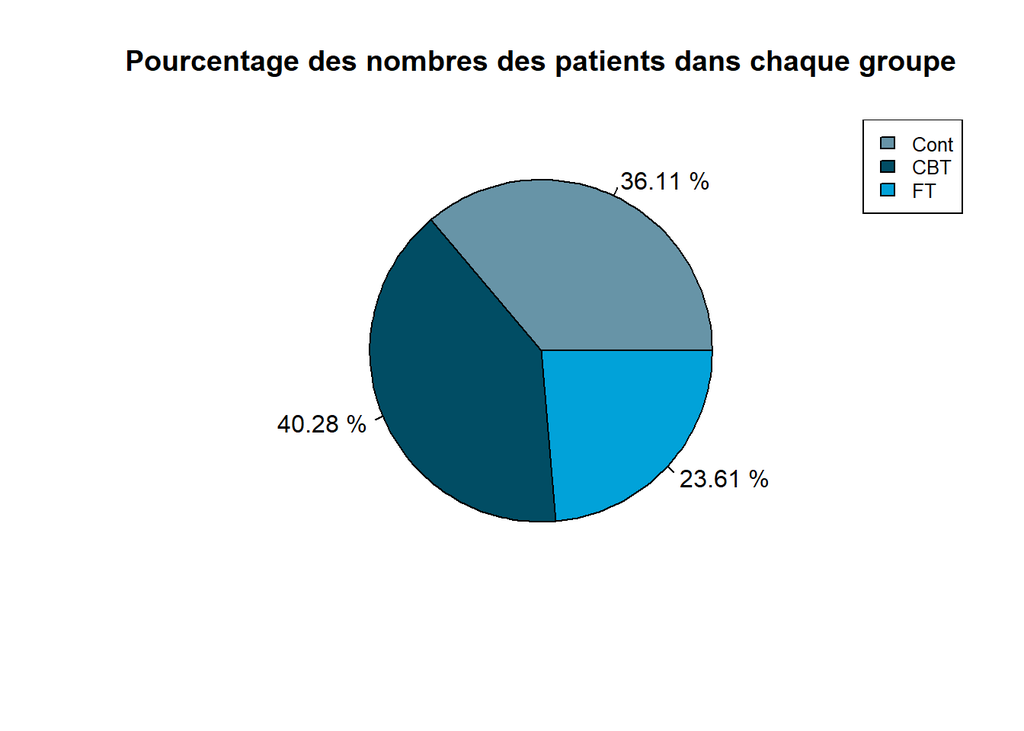

A l’aide du diagramme camembert ci-dessus, nous trouvons que la différence des nombre de patients du groupe `Cont` et du groupe `CBT` est négligeable, par contre, la proportion du groupe `FT` est assez petite en comparaison. En fait, le nombre des patients du groupe `FT` ne représente que 58.62% du celui du groupe `CBT`. Mais leur proportions sont dans le même niveau, donc c’est un défaut pas grave et nous pouvons nous autoriser de continuer notre étude.

## 2.2 Comparaison des distributions du poids des patients au début de l’étude

D’abord, par les histogrammes du nombre de patients, nous avons vu que ceux du groupe `CBT` et du groupe `FT` étaient similaires. Mais on ne peut rien conclure sur l’histogramme du groupe `Cont`.

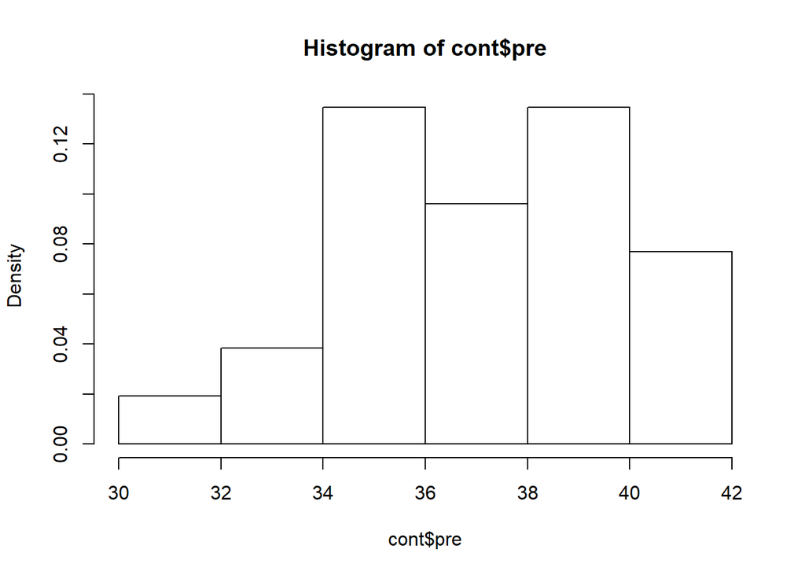

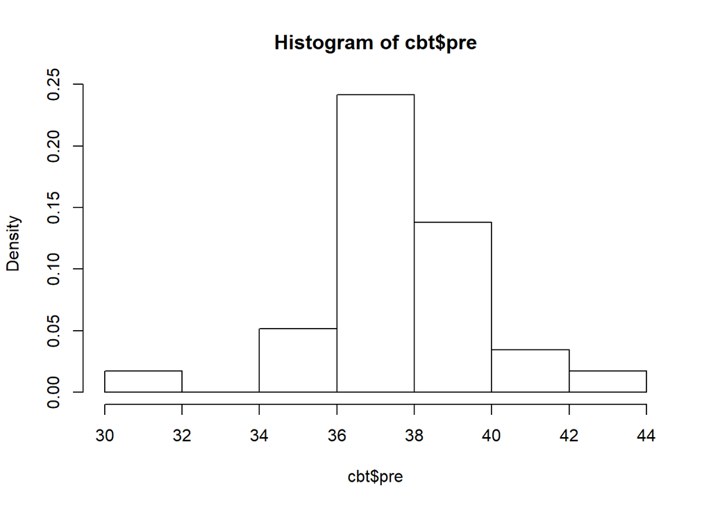

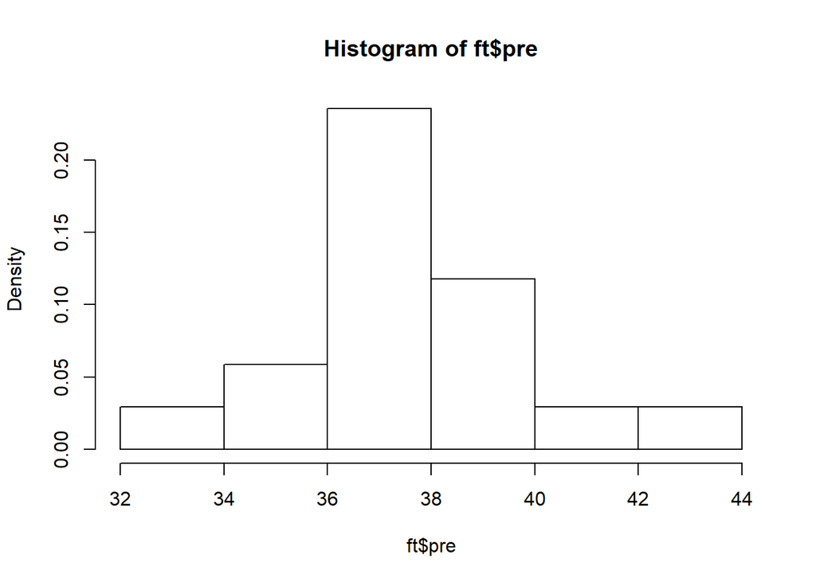

Ensuite, par la boîte à moustaches, nous avons eu une vue globale des états de leur distribution, et nous avons trouvé qu’il y avait une relativement petite différence entre leur domaine de distribution.

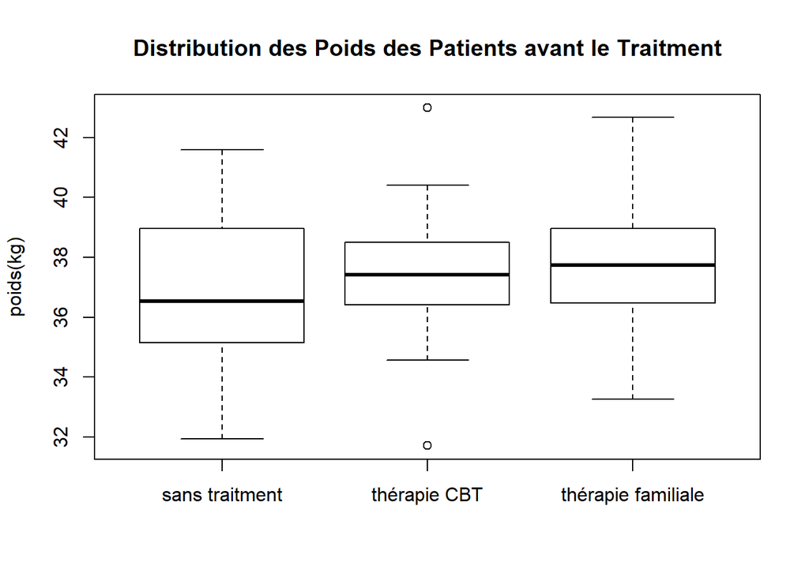

Figure 2.1: Distribution des Poids des Patients avant le Traitment

|  | Min. | 1st Qu. | Median | Mean | 3rd Qu. | Max. | Std. |
| --- | --- | --- | --- | --- | --- | --- | --- |
| Cont | 31.94 | 35.21 | 36.53 | 36.95 | 38.9 | 41.59 | 2.59 |
| CBT | 31.71 | 36.42 | 37.42 | 37.46 | 38.51 | 42.99 | 2.2 |
| FT | 33.25 | 36.47 | 37.73 | 37.7 | 38.96 | 42.67 | 2.27 |

De plus, le diagramme quantile-quantile visualise directement la comparaison de leur distribution.

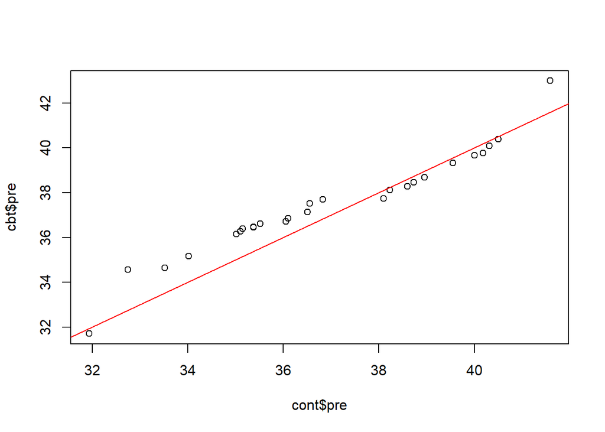

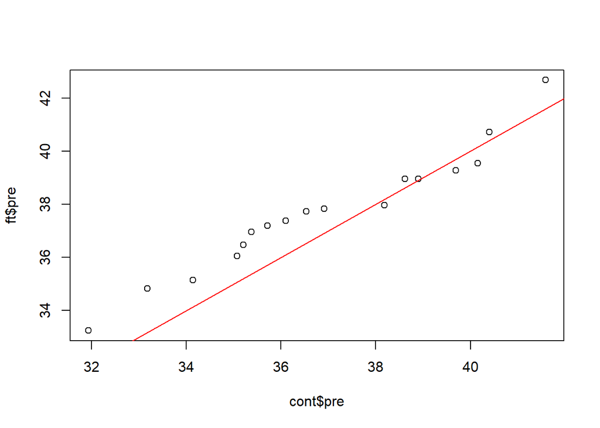

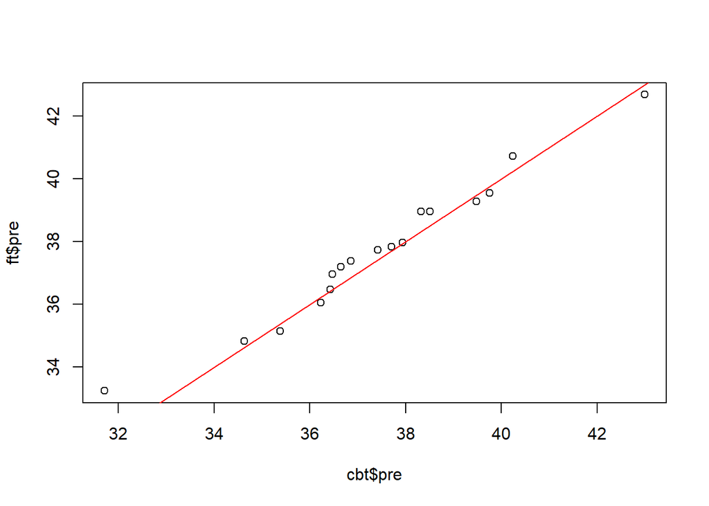

Donc, nous avons bien vérifié que la composition des trois groupes de patients qui suivent des traitements différents à été bien faite. Notre l’étude a alors été correctement menée.

# 3 Evaluation du succès d’un traitement

Dans ce contexte médical, on ne peut pas juger la validité d’un traitement en simplement comparant le poids des patients à la fin de l’étude. Parce que d’un part, il y a des différences du poids des patients au début de l’étude entre les groupes, donc le poids des patients à la fin de l’étude d’un groupe est plus élevé que celui d’un autre groupe ne signifie pas forcément qu’il y avait un augment du poids des patients. D’autre part, un traitement peut faire des impacts différents sur différents patients. Par exemple, une partie des patients gagne du poids et l’autre en perd, mais la distribution du poids des patients à la fin peut être similaire avec celle au début. Une méthode raisonnable est donc d’apparaître le changement du poids des patients, c’est-à-dire, on compare les variations de poids durant l’étude. Donc, nous rajoutons la colonne `diff` comme la différence entre la valeur `pre` et la valeur `post`, qui représente l’impact d’un traitement à un patient.

# 4 Evolution du poids des patients qui n’a suivi pas aucun traitement

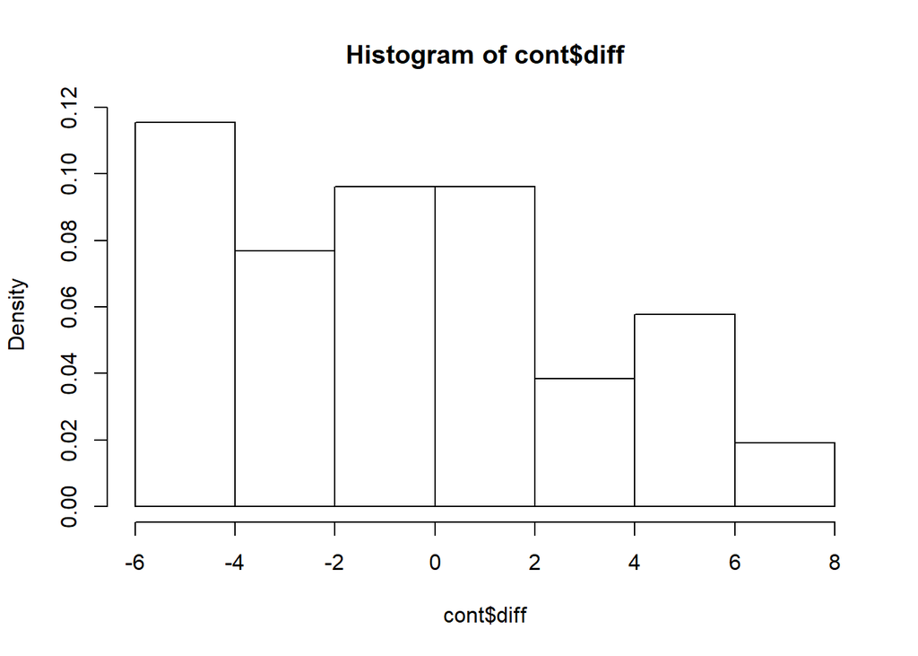

Et puis, nous avons calculé en plus de détailles les informations de ses quantiles, de sa moyenne et de sa variance.

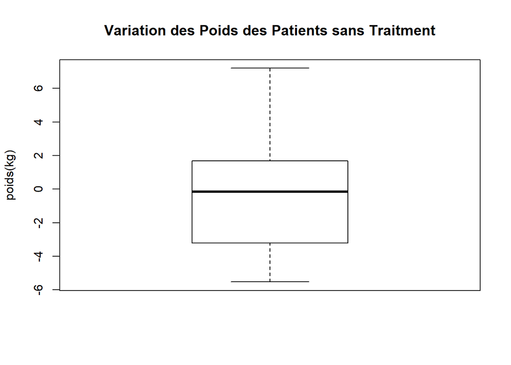

|  | Min. | 1st Qu. | Median | Mean | 3rd Qu. | Max. | Std. |
| --- | --- | --- | --- | --- | --- | --- | --- |
| Cont | -5.53 | -3.17 | -0.16 | -0.2 | 1.63 | 7.2 | 3.62 |

D’après les résultats ci-dessus, nous concluons que plus de la moitié des personnes ont perdu du poids, et que chacun perd 0,2 kg en moyenne.

# 5 Comparaison des trois traitements

Pour trouver la meilleure méthode entre les trois, nous les comparons par leur boîte à moustaches. Et nous voyons que la thérapie familiale se comporte le meilleur sur chaque indicateur statistique.

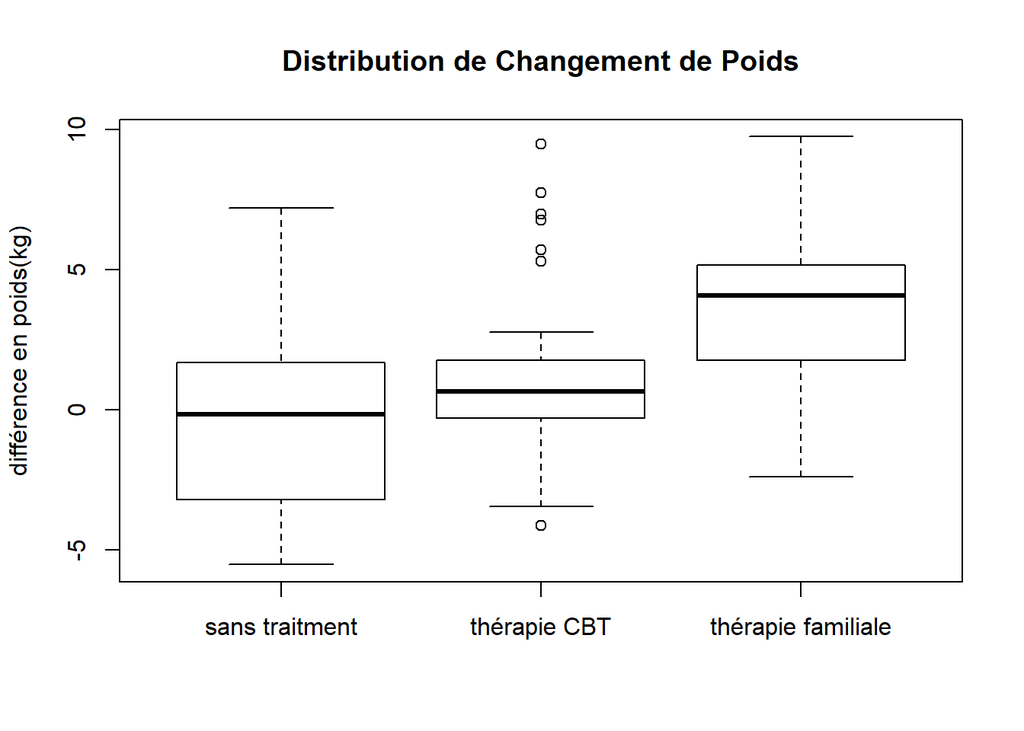

Figure 5.1: boxplot de différence de poids

En fait, parmi les trois groupes, pour le traitement `FT`, les poids minimal et maximal, les quantiles médian, de première quatrième et de troisième quatrième et la valeur moyenne sont tous les plus élevés. Cela signifie que la thérapie a le meilleur impact aux patients. De plus, sa variance est la plus petite parmi les trois groupes. C’est-à-dire, cette thérapie est la plus stable.

|  | Min. | 1st Qu. | Median | Mean | 3rd Qu. | Max. | Std. |
| --- | --- | --- | --- | --- | --- | --- | --- |
| Cont | -5.53 | -3.17 | -0.16 | -0.2 | 1.63 | 7.2 | 3.62 |
| CBT | -4.12 | -0.32 | 0.63 | 1.36 | 1.77 | 9.47 | 3.31 |
| FT | -2.4 | 1.77 | 4.08 | 3.29 | 5.16 | 9.74 | 3.24 |

Donc, d’après nous, la thérapie familiale est le meilleur traitement parmi les trois.

# 6 Distribution des différentes variables liées au poids

A la fin de notre étude, nous faisons une analyse supplémentaire pour vérifier si la distribution des différentes variables liées aux poids peut être modélisée par une loi normale. Donc, nous analysons la distribution des variables pre, post et diff pour chaque groupe par le diagramme quantile-quantile et le teste de Kolmogorov-Smirnov.

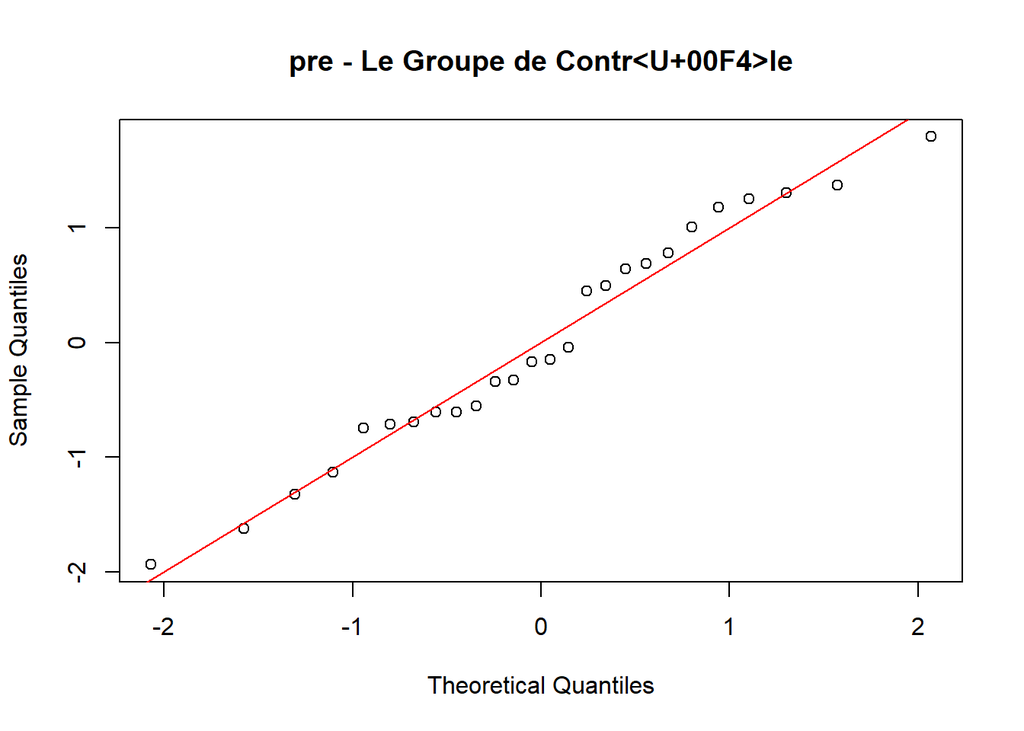

Figure 6.1: qbc

```
##
##  One-sample Kolmogorov-Smirnov test
##
## data:  std
## D = 0.098192, p-value = 0.9635
## alternative hypothesis: two-sided
```

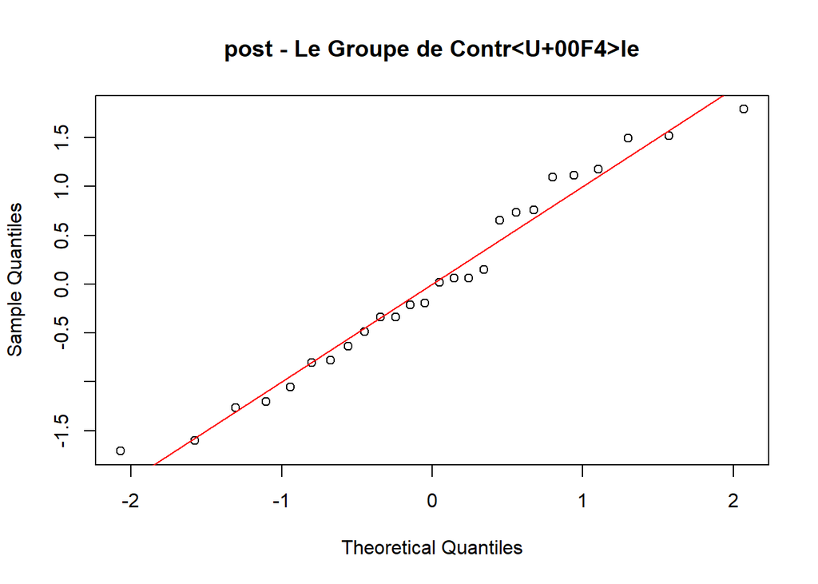

Figure 6.2: qbc

```
##
##  One-sample Kolmogorov-Smirnov test
##
## data:  std
## D = 0.095836, p-value = 0.9707
## alternative hypothesis: two-sided
```

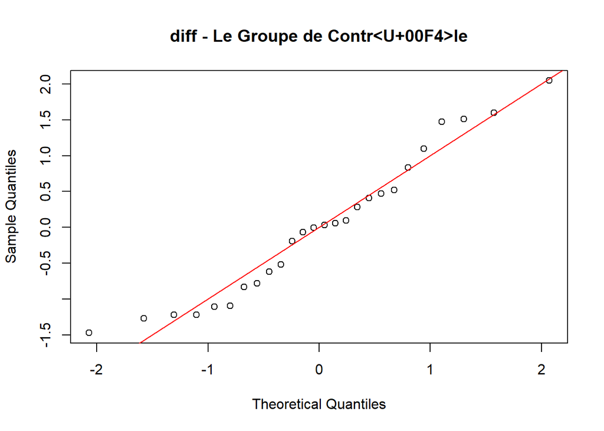

Figure 6.3: qbc

```
##
##  One-sample Kolmogorov-Smirnov test
##
## data:  std
## D = 0.094076, p-value = 0.9589
## alternative hypothesis: two-sided
```

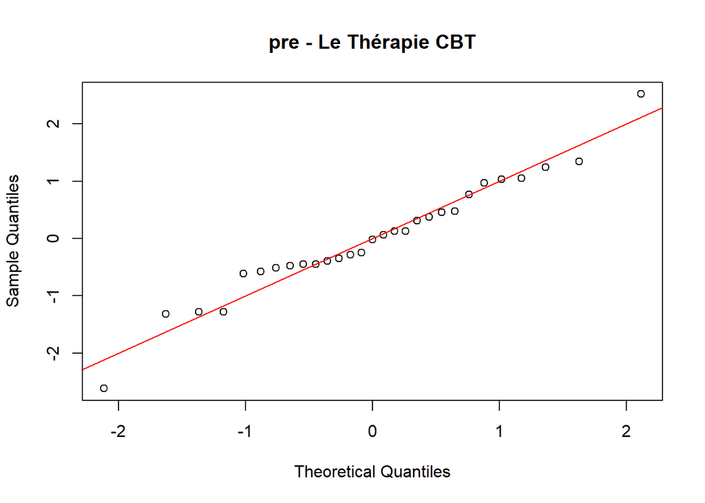

Figure 6.4: qbc

```
##
##  One-sample Kolmogorov-Smirnov test
##
## data:  std
## D = 0.13069, p-value = 0.7049
## alternative hypothesis: two-sided
```

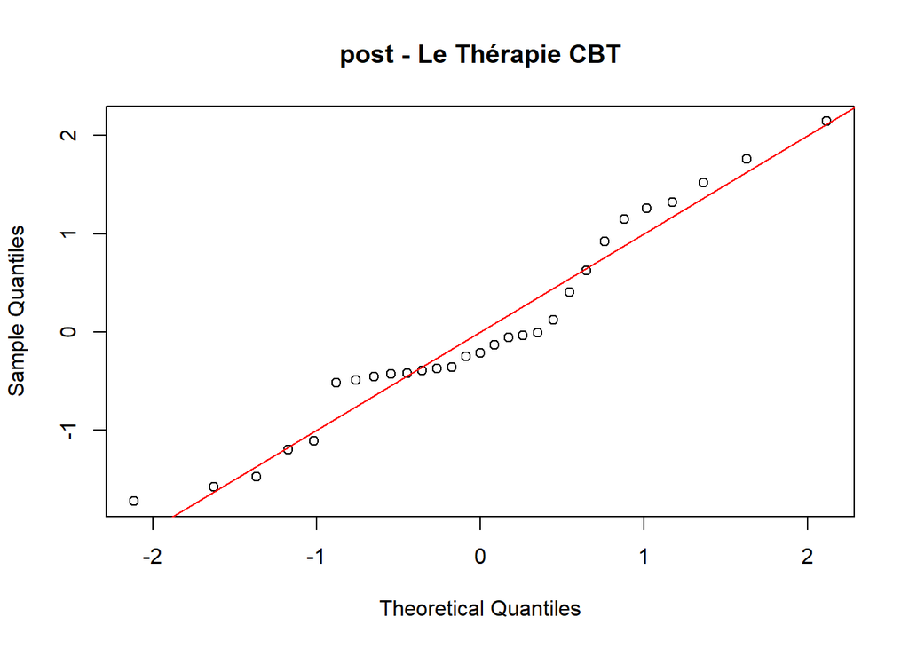

Figure 6.5: qbc

```
##
##  One-sample Kolmogorov-Smirnov test
##
## data:  std
## D = 0.15978, p-value = 0.4068
## alternative hypothesis: two-sided
```

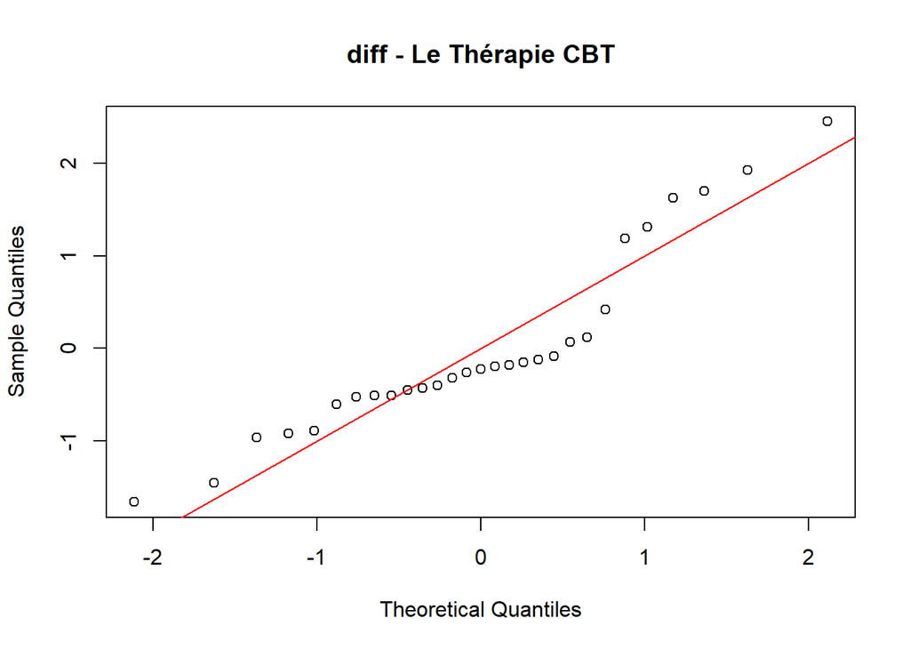

Figure 6.6: qbc

```
##
##  One-sample Kolmogorov-Smirnov test
##
## data:  std
## D = 0.22275, p-value = 0.09587
## alternative hypothesis: two-sided
```

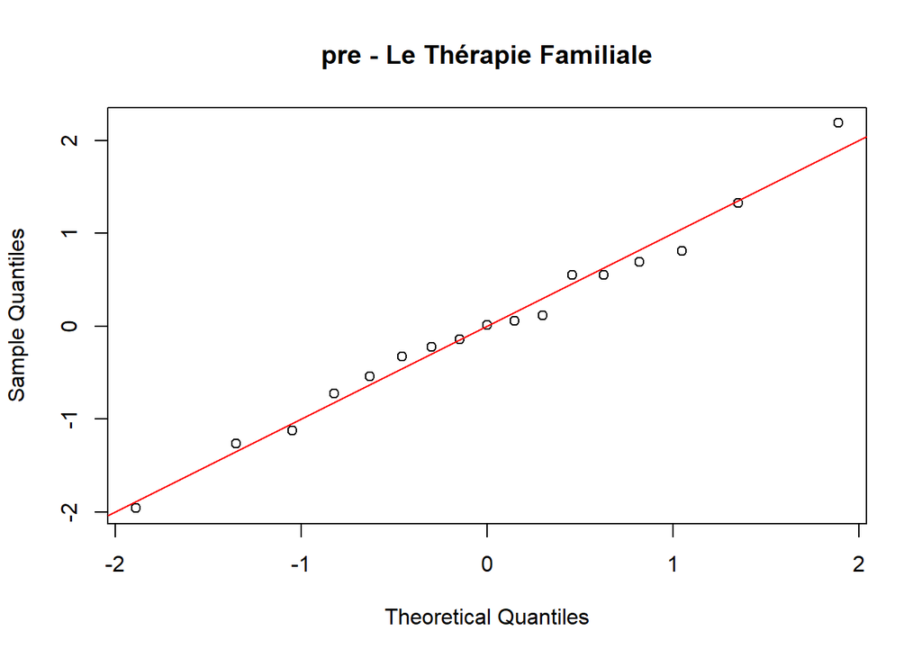

Figure 6.7: qbc

```
##
##  One-sample Kolmogorov-Smirnov test
##
## data:  std
## D = 0.10178, p-value = 0.9946
## alternative hypothesis: two-sided
```

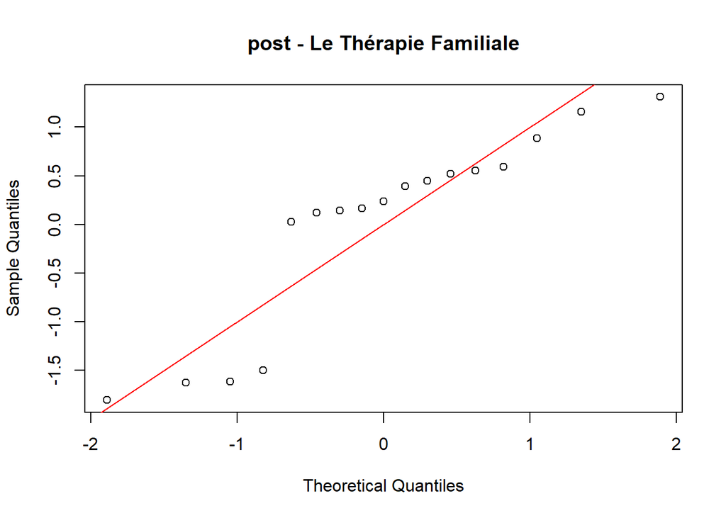

Figure 6.8: qbc

```
##
##  One-sample Kolmogorov-Smirnov test
##
## data:  std
## D = 0.2744, p-value = 0.1271
## alternative hypothesis: two-sided
```

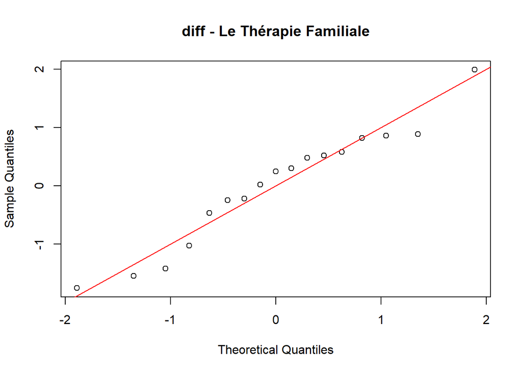

Figure 6.9: qbc

```
##
##  One-sample Kolmogorov-Smirnov test
##
## data:  std
## D = 0.12922, p-value = 0.905
## alternative hypothesis: two-sided
```

# 7 Conclusion

Vue les analyses précédentes, nous avons vérifié que la composition des trois groupes de patients qui suivent des traitements différents avait été bien faite. Et, on peut choisir les variations de poids durant l’étude comme une méthode raisonnable de l’évaluation du succès d’un traitement. Par cette méthode, nous avons trouvé qu’un patient perdrait du poids de 0,2 kg en moyenne s’il ne suit aucune thérapie. Au contraire, les traitements CBT et FT sont en général valables pour les patients de l’anorexie. Et le traitement FT est le plus efficace entre les deux.